# Classification

The art of fitting messy data into neat boxes

More often than not the world that we live in (and measure, and analyze) is full of variation, random noise, and continuous, gradual phenomena. On the other hand, our minds have evolved dealing with *concepts* and *categories* in which we organize our perception of reality and extract meaning from it.

This sets up an interesting conflict, one that will be left for epistemologist to solve, but that will give us something to think about: computational protocols are human-made tools, and as such, they are adapted to our goals and in many ways inherit our cognitive biases and mental structures.

Methods that categorized observations in computer science can be largely divided in two main groups, depending on the goal of the project and the information that we have on our data:

- Supervised Learning:
  - Uses labeled data, we know beforehand the class that every element belongs to
  - The main goal of the process is finding what characteristics separate the elements in our data into their classes.
  - The most common application of supervised classification methods is **creating predictive models**.
- Unsupervised Learning
  - Uses unlabeled data, that is, the elements in our dataset might belong to different classes of a particular characteristic, but we do not know it in advance.
  - The main goal of the process is to group together the elements in our dataset that are similar.
  - The most common application of unsupervised learning methods is **discovering categorical distinctions** in a diverse dataset and **building profiles** of each of the groups.

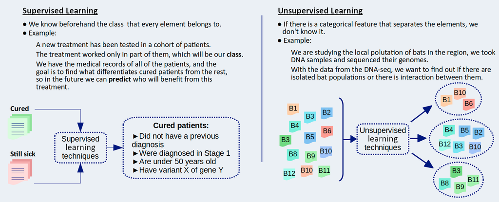

### Supervised Learning

As mentioned above, these classification methods are usually applied in order to create predictive models. The general concept behind it is that, if we find a set of rules which can separate properly the data that we already have, that same model could be applied to new data and reliably predict to which category they should belong to.

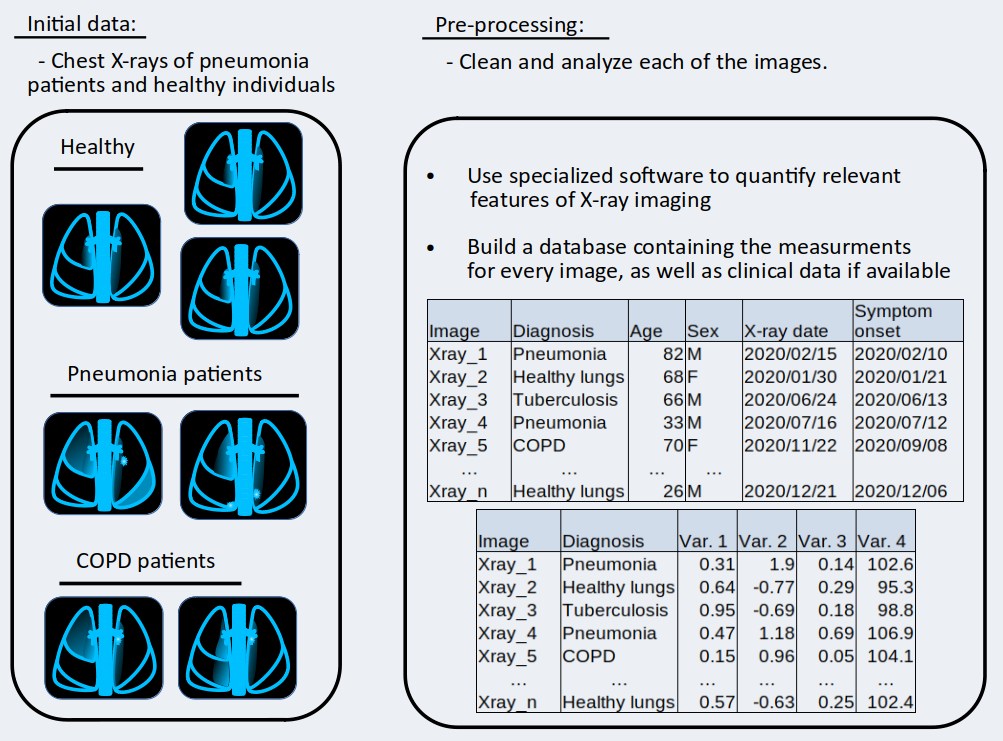

Let’s illustrate the process with an example.  
Let’s say the goal is to create a predictive model that can distinguish between different pulmonary diseases in X-ray images. A research team in a hospital has gathered chest X-rays of several patients, as well as individuals without any lung condition, and in addition to that we have a brief clinical history of the patients.  
The first step done by the research team will be to process and analyzed the images, usually with specialized software, to quantify relevant characteristics of the chest X-ray images - such as area or density of alveolar opacities -. The resulting database, combining clinical background and image features would be our initial dataset.

Supervised learning procedures have many variations depending on the type of data they were design to handle, but for the most part they go through three general steps:

- **Splitting the initial dataset**: two partitions will be generated:
  - Training dataset: which will be used in the training phase.
  - Testing dataset: which will be used in the validation phase. This step could be skipped if there were external validation methods available.
- **Training**: this is the phase in which a predictive model is generated. Each particular algorithm will have a different internal protocol, but the main purpose is the same: to analyze the training dataset and find the boundaries between the different types of elements. The end result will generally be a set of rules that, if met, will assign a class to each new sample (within a certain probability margin).
- **Validation**: Now the model generated in the training phase will be tested to measure its predictive capability. In this phase the elements in the testing split will be fed to the classifier as if they were new data, and then the predicted labels will be compared to the real labels of each case in order to assess the performance of classifier generated.

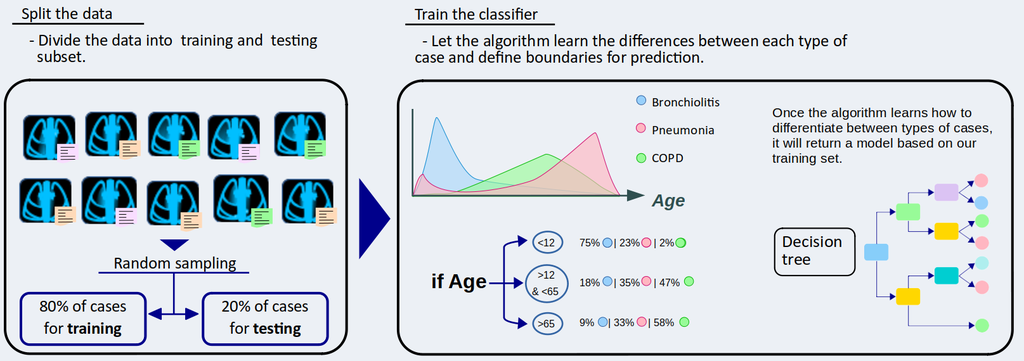

*Following our example case with chest X-rays, after we have the initial dataset with clinical and image data, the first step to create a predictive model will be to split the data in two groups, for instance, sampling the cases randomly.*  
*Once we have the training set ready, we’ll run the classification algorithm. For this example we have chosen to generate a decision tree, which can work with both categorical (sex, previous diagnosis…) and numerical (age, image processing measurements…) data. In the illustration we depict a hypothetical case with the feature **Age**, and its relationship with three diseases: each of the diseases is more or less prevalent at different stages, so the algorithm can calculate the optimal age brackets that correlate better with the diagnoses. The algorithm will continue this process with different features in our dataset, finding combinations of features and values that best define the cases in our training dataset.*  
*In this example, after running the algorithm we will get a “decision tree”, a type of classifier in which we start evaluating a feature and move through one branch or other to the next level depending on the answer:*  
*“Is age over 65? Yes → Are there alveolar opacities in over 50% of the lung area? […] → with this characteristics, COPD was the most common diagnosis in the training dataset”.*

*After we have a predictive model comes the validation phase. Using the selection of cases kept aside for testing,we’ll feed them to the classifier we have just generated and then compare model’s diagnoses to the real diagnoses.*

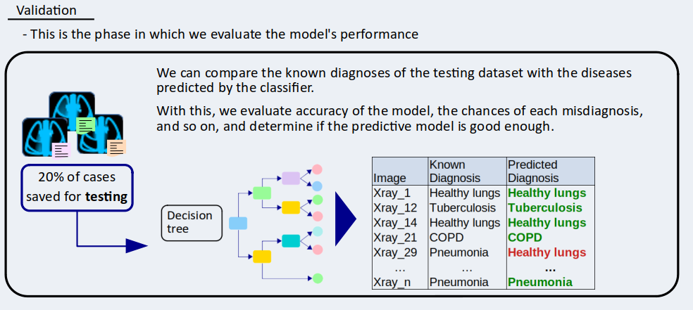

In this example we have described the process to generate one individual classifier, but ideally this process would be repeated several times varying the split of cases between the training and testing groups in order to generate models with slightly different criteria, and then select the one that did better in the validation phase.

In addition to saving part of our data, there are also *external validation* mechanisms, that is, using another dataset that was obtained independently from the one we used. In our lung disease example, an external validation mechanism could be asking colleagues in other hospitals for a sample of chest X-rays from their patients. This external validation strategies will help us to check if the predictive model we have made is susceptible to several types of biases, like technical details of an x-ray machine or demographic biases in the patients of each hospital.

### Unsupervised learning

Clustering is one of the most common and recognizable steps in scRNA-seq analysis. In this context the goal of clustering operations is to group similar cells together with the presumption that the underlying reason that causes differences in gene expression is cell type.

Cell clusters will become the “class” variable that separates our cells in discrete groups, and as such, they will be the foundation for later analysis (differential expression, cell type imputation…). This is the reason why understanding how clustering processes work will help us analyzing and interpreting single-cell RNA-seq results.

#### ¿How do we evaluate clustering results?

Since in this case we do not know the category that each element belongs to, we can’t rely on comparing the clustering results we got to the real labels we expected to get. Many clustering algorithms base their evaluation in the principle that «*cluster partners should be similar to each other and different from members of other clusters*».

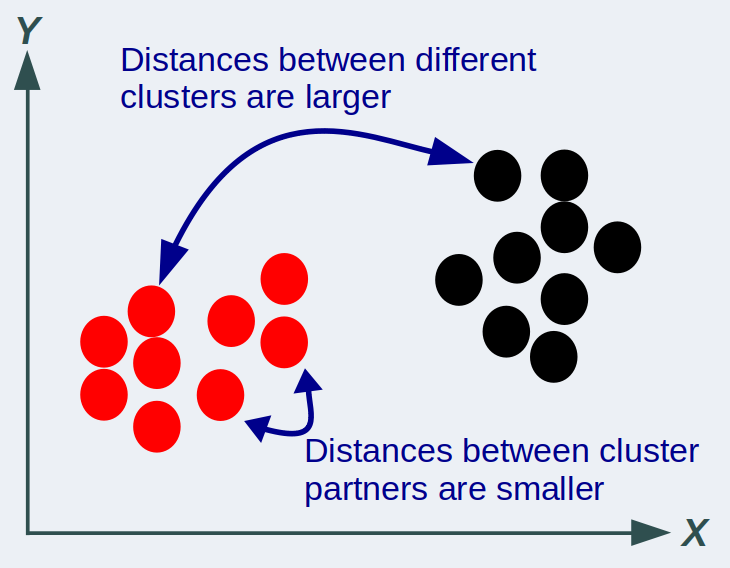

This might sound obvious at first glance, but the greater differences between clustering methods lie here: how is *similarity* quantified and *what steps to take* to try and maximize this similarity between cluster partners and minimize it with members of other clusters.

Let’s illustrate this with an example. We can use the [Iris dataset](https://en.wikipedia.org/wiki/Iris_flower_data_set), a table containing measurements of petals and sepals of several species of Iris flowers:

|  | Sepal Length | Sepal Width | Petal Length | Petal Width | Species |
| --- | --- | --- | --- | --- | --- |
| 1 | 5.1 | 3.5 | 1.4 | 0.2 | setosa |
| 2 | 4.9 | 3.0 | 1.4 | 0.2 | setosa |
| 3 | 4.7 | 3.2 | 1.3 | 0.2 | setosa |
| 4 | 4.6 | 3.1 | 1.5 | 0.2 | setosa |
| 5 | 5.0 | 3.6 | 1.4 | 0.2 | setosa |
| 6 | 5.4 | 3.9 | 1.7 | 0.4 | setosa |

After plotting, for example, petal length VS sepal length, we could divide the flowers in different numbers of clusters:

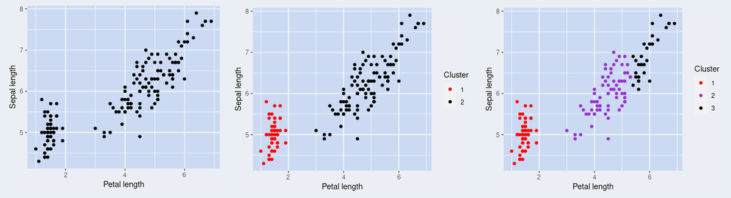

We can calculate the euclidean distance between each pair of points, and then check if cluster partners are closer than non-partners:

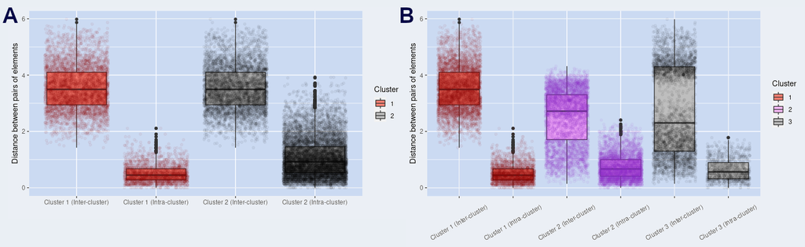

*Distances between cluster partners and non-partners when dividing the points in two clusters (A), or three clusters (B).*

Now, how could we know which clustering result is better? There are many alternatives, some simple and some quite sophisticated. For this example we could take one of the most straight-forward approaches and “score” each clustering result based on the difference between mean partner distances and mean non-partner distances. Once we have our scoring criteria, we can take a systematic approach and find the “optimal” solution within the range tested. For example, increasing the number of clusters:

|  | Number_clusters | mean Partner Dist. | mean Non-Partner Dist | Difference |
| --- | --- | --- | --- | --- |
| 1 | 2 | 0.9528310 | 3.535236 | 2.582405 |
| 2 | 3 | 0.6593690 | 2.927399 | 2.268030 |
| 3 | 4 | 0.5557771 | 2.773482 | 2.217705 |
| 4 | 5 | 0.5305689 | 2.647875 | 2.117306 |
| 5 | 6 | 0.5012013 | 2.607827 | 2.106626 |
| 6 | 7 | 0.4339672 | 2.437858 | 2.003891 |
| 7 | 8 | 0.4229650 | 2.432491 | 2.009526 |
| 8 | 9 | 0.4175181 | 2.429674 | 2.012156 |
| 9 | 10 | 0.3644545 | 2.397541 | 2.033086 |
| 10 | 11 | 0.3583372 | 2.391133 | 2.032796 |
| 11 | 12 | 0.3478542 | 2.372622 | 2.024768 |
| 12 | 13 | 0.3444129 | 2.366271 | 2.021858 |
| 13 | 14 | 0.3225149 | 2.340904 | 2.018389 |
| 14 | 15 | 0.3205706 | 2.339319 | 2.018749 |

*If we plot the distances it’s easy to see that **two clusters** is the solution that maximizes our scoring function:*

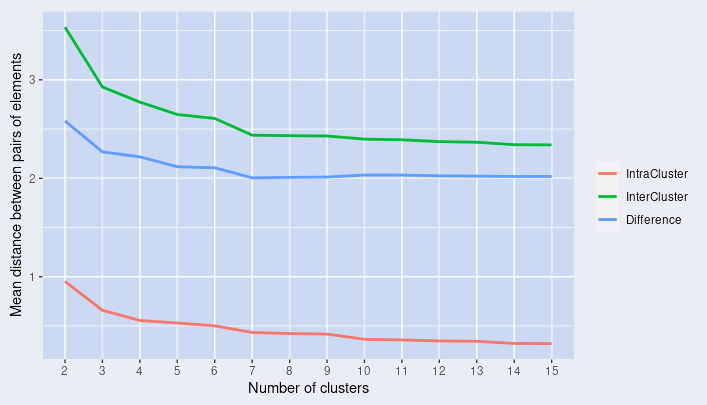

*Therefore, in this case, we could say that this Iris flowers can be separated in two categories based on petal and sepal length. Once we have the two categories, we could study what makes them different and annotate each category:*

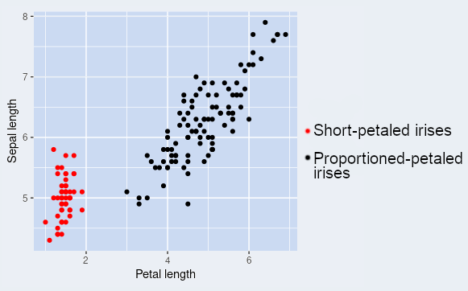

At the end of the day the Iris dataset contains only four measurements of 150 flowers, so this process can seem too much work to get a result that we could have reached even just by taking a look at the initial plot. But having analytical tools to evaluate and compare clustering results becomes essential the moment we work with more complex datasets, specially if our visualization tools represent a transformation of the data and not the raw values, which will be the case in single cell analysis.

#### Shared Nearest Neighbors clustering (SNN)

Measurements of similarity (like Euclidean distance, used in the previous example) can become less helpful when working with high-dimensional datasets. The clustering method implemented in the Seurat software package (an thus, used in this app) to process single-cell RNA-seq data is based on the *Shared Nearest Neighbors* algorithm or *SNN*. Because of this, we will give a brief explanation of how the SNN algorithm works.

The SSN algorithm will cluster points together based on their *shared neighbors*, that is, if the closest points to **A** are also the closest points to **B**, **A** and **B** will be assigned to the same cluster. The algorithm finds the most interconnected points and uses them as cores to define the final clusters.

This will be more clear on a step-by-step example. Lets say that we have a set of 12 cells and a matrix of similarity between their transcriptomes:

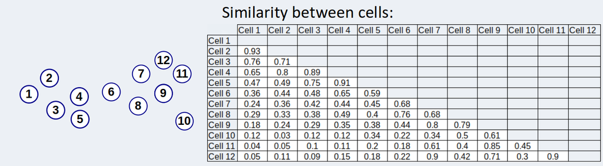

The first step will be determining what we will consider “*similar enough*”, or how large the neighborhood of a cell will be. Since this is a very small dataset, we’ll define the ‘neighborhood’ of a cell as the 3 most similar cells. In each row of the table we keep the three highest similarities:

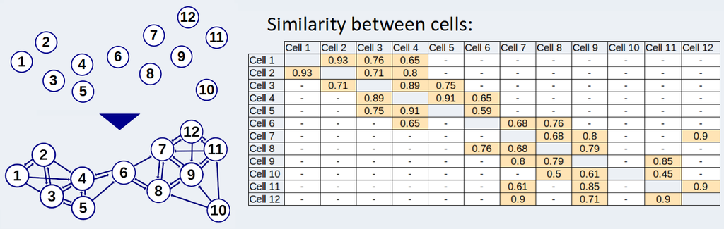

From this initial network we’ll filter out the links with lower similarity values, in this case, we’ll chose 0.6 as a minimum value:

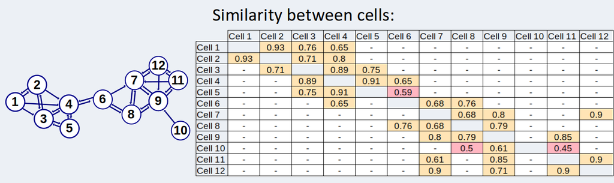

The next step is finding the “shared neighborhood” between pair of cells.  
For instance, both cells 1 and 2 are connected to 3 and 4, so their shared neighborhood is of size 2.  
With another neighbor of cell 1, cell 3, the shared neighborhood is also of size 2 (both are connected to cells 2 and 4).  
And finally, with cell 4, cell 1 only shares one neighbor, which would be cell 3.

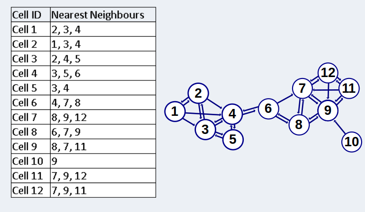

The goal of this step is to find the most interconnected cells (what in this method is called “density of a point”), which could be considered the “central piece” or *core* of each cluster. When the shared neighborhoods of every cell are calculated, we’ll end up with a matrix like this:

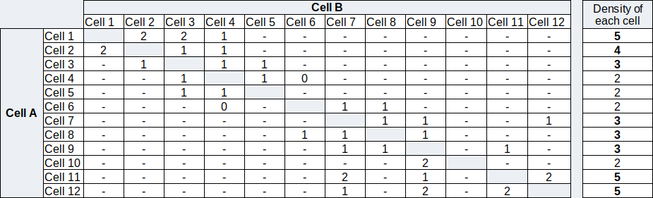

The density of each cell is calculated by adding up the sizes of its shared neighborhoods. The cells with a density greater than 2 will be our core points. The rest of the points will be assigned to the cluster they are closest to (within a minimum). Cells that are not close enough to any cluster can be kept as singletons or discarded as noise:

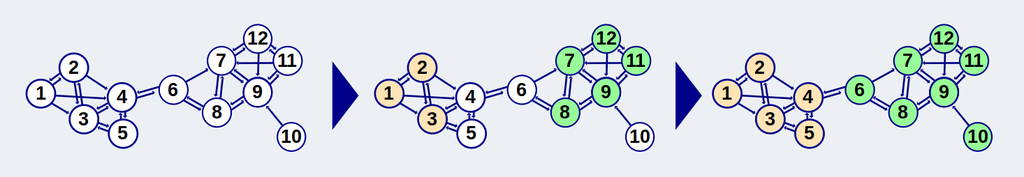

**More resources**

- [An in-depth guide to supervised machine learning classification](https://builtin.com/data-science/supervised-machine-learning-classification)
- [Modern Statistics for Modern Biology, Ch. 12, Supervised learning](https://web.stanford.edu/class/bios221/book/Chap-Supervised.html).
- [Modern Statistics for Modern Biology, Ch. 5, Clustering](https://web.stanford.edu/class/bios221/book/Chap-Clustering.html)